# supp

PhD Defense · Complete corpus

The Hippocampal-to-Ventricle Ratio

A self-normalizing biomarker for medial temporal integrity  
across the Alzheimer’s disease continuum

Sofía Fernández-Lozano · Supervisor: Louis Collins

[figure not shown]

[figure not shown]

[figure not shown]

Q&A backup

Background

Anatomy, AD pathology, head-size correction, normative modelling,  
and the methods used across Ch3–Ch6

Background · The hippocampus

Medial temporal structure for declarative memory

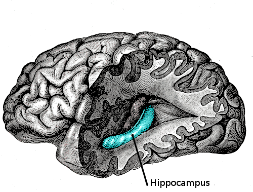

**Subregions**

- **CA1–CA4** (cornu ammonis)
- **DG** (dentate gyrus)
- **Subiculum**

**Role**

- Episodic memory encoding
- Spatial navigation
- One of the earliest AD targets

Background · HC anatomy (deeper)

Subfields and the trisynaptic circuit

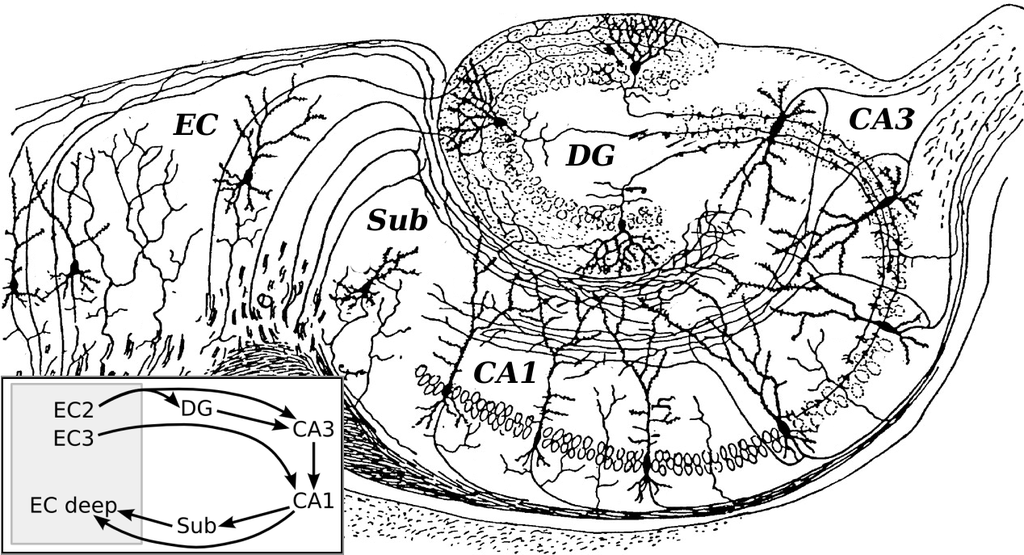

**Circuit**

EC → DG → CA3 → CA1 → Sub.

**Pathology**

Tau begins in transentorhinal cortex  
→ CA1 / subiculum (Braak I–II)  
→ early atrophy signature.

CA1 and subiculum bear  
the **early Braak load**.

Ramón y Cajal, 1909 · Yushkevich et al., 2015 · Apostolova et al., 2006

Background · AD pathology

Braak staging — MTL involved at Stages I–II

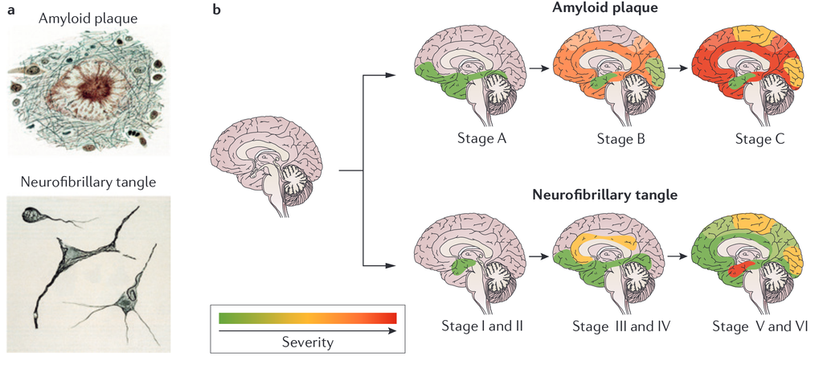

**Two pathologies**

- **Amyloid-β**  
  extracellular plaques
- **Tau**  
  intracellular tangles

**Braak progression**

- **I–II**: transentorhinal / MTL
- III–IV: limbic
- V–VI: isocortical

Background · Diagnostic framework

NIA-AA shifted AD from clinical to biological

| Year | Framework | Components |
| --- | --- | --- |
| **2018** | AT(N) | **A**myloid · **T**au · **N**eurodegeneration |
| **2024** | AT₁T₂NISV | + **I**nflammation · **S**ynuclein · **V**ascular |

**Why it matters**

- AD now diagnosed by **biomarkers**,  
  not clinical syndrome
- Preclinical AD can exist without symptoms
- Late-life decline often involves  
  **co-pathologies**
- Structural MRI → **N** marker

Jack et al., 2018 · Jack Jr. et al., 2024

Background · Disease continuum

Preclinical → MCI → dementia

| Stage | Cognition | Function |
| --- | --- | --- |
| **Preclinical** | Normal | Independent |
| **MCI** | Objective decline | Independent |
| **Dementia** | Severe impairment | Dependent |

MCI patients with hippocampal atrophy rates >3% / yr  
typically convert to AD dementia.

**Clinical definitions**

- **Preclinical:**  
  biomarker+ no symptoms
- **MCI:**  
  noticeable decline, daily life preserved
- **Dementia:**  
  multi-domain impairment, loss of independence

**HC atrophy rate**  
differentiates progressive  
vs stable MCI.

Jack et al., 2000 · Franko & Joly, 2013 · Barnes et al., 2009

Background · Differential diagnosis

Late-life cognitive decline ≠ always AD

**Common dementia etiologies**

- **Alzheimer’s disease**  
  — amyloid + tau, medial temporal lobe onset
- **Frontotemporal dementia**  
  — frontal/temporal atrophy
- **Lewy body dementia**  
  — α-synuclein, parkinsonism
- **Vascular dementia**  
  — infarcts, white-matter lesions
- **Hippocampal sclerosis of aging**  
  — mimics AD on MRI

**Why this matters for HVR**

- Hippocampal atrophy is  
  **not specific to AD**
- Biological AD confirmation  
  (amyloid + tau + N)  
  reduces misclassification
- Ch6 cohort:  
  **amyloid-positive only**  
  (A+ on PET or CSF)

Jack Jr. et al., 2024 · Kobayashi et al., 2024

Background · Genetic risk

APOE ε4 hits females harder

**APOE ε4 carriers**

- ε4 is the **strongest genetic risk**  
  for late-onset AD
- Risk is **greater in females** than males
- Female ε4 carriers (amnestic MCI):  
  faster HC atrophy + cognitive decline
- Cognitively normal female ε4+:  
  more MTL tau at similar amyloid burden

**Why it matters here**

- Motivates **sex-stratified** models  
  in Ch5
- Sex × genetic risk × structure interactions  
  can’t be averaged away

Ferretti et al., 2018 · Park et al., 2025 · Buckley et al., 2019

Background · Reserve

Cognitive reserve delays clinical expression

**The concept**

- Two people with **equivalent pathology**  
  can show different clinical symptoms
- Education, occupation, lifelong  
  cognitive engagement → higher reserve
- Reserve **delays the symptom threshold**,  
  not pathology itself

**Sex-specific reserve**

- Females show a **verbal memory advantage**  
  that masks early MTL atrophy
- May explain later female AD diagnosis  
  at equivalent pathology

Stern, 2012 · Sundermann et al., 2016

Background · Modifiable risk factors

~45% of dementia is potentially preventable

- **Midlife:**  
  hypertension, obesity, hearing loss, alcohol, head injury
- **Late life:**  
  smoking, depression, social isolation, physical inactivity, diabetes, air pollution
- **Newly added 2024:**  
  high LDL cholesterol, untreated vision loss

**Why this matters**

- Frames Ch6’s focus on  
  **cardiovascular risk** (FRS)
- Modifiable ≠ deterministic;  
  many factors interact with age + APOE

Livingston et al., 2017 · Livingston et al., 2024

Background · Biomarker cascade

A late, but crucial marker

Neurodegeneration (N)  
follows amyloid (A) and tau (T)

2024 NIA-AA AT<sub>1</sub>T<sub>2</sub>NISV  
treats structural markers as  
**severity indicators**,  
not diagnostic features.

HC atrophy emerges  
around MCI onset —  
decades after amyloid abnormality.

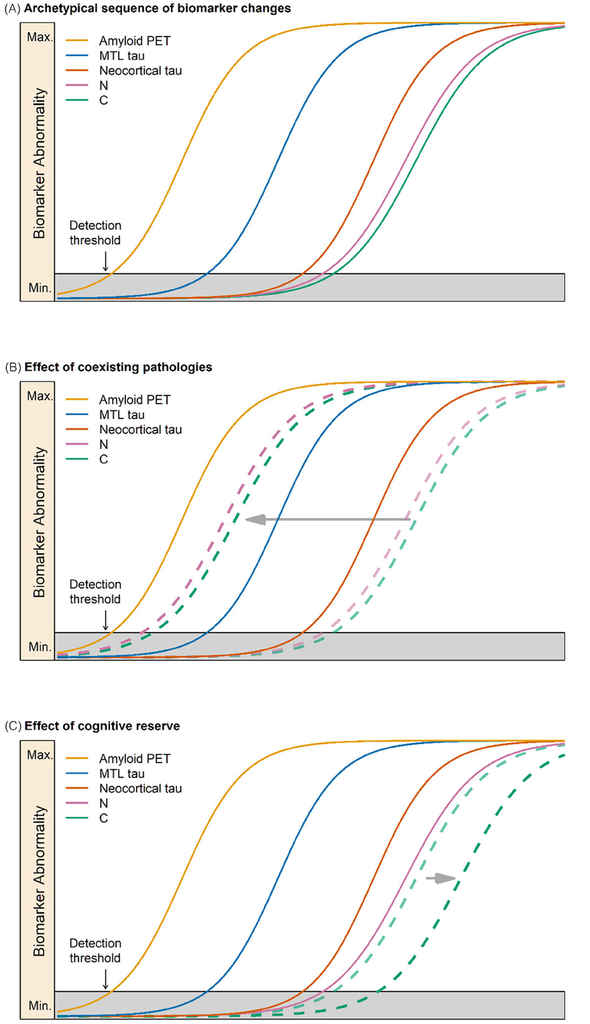

Jack Jr. et al., 2024

Background · Biomarker modalities

Many AD biomarkers — why structural MRI?

| Modality | Reads | Stage |
| --- | --- | --- |
| **CSF** | Aβ42/40, p-tau, t-tau, NfL | Pre + clinical |
| **PET** | Amyloid (Aβ), tau, FDG | Pre + clinical |
| **Blood** | p-tau217, GFAP, NfL | Emerging |
| **MRI** | **N** (atrophy, WM lesions) | Mid-late |

**Why structural MRI**

- **Non-invasive**, routine in clinical practice
- Direct measure of **neurodegeneration** (N in ATN)
- HVR is computed from a standard T1w scan

Jack et al., 2018 · Jack Jr. et al., 2024

Background · Measurement challenge

HC volumes diverge across segmentation software

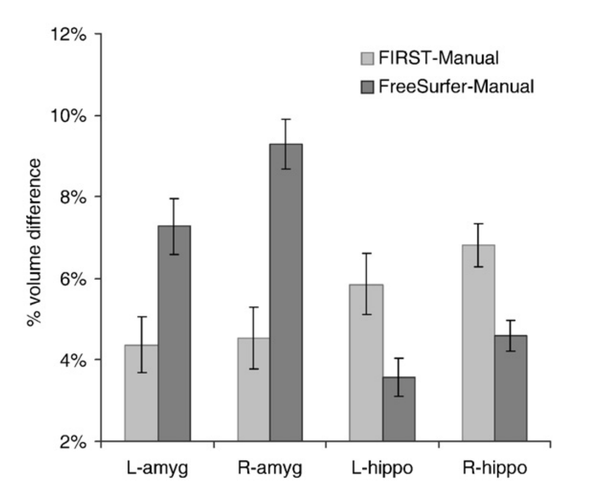

**Across-tool variability**

- FIRST vs FreeSurfer vs manual  
  diverge by **4–9%**
- Choice of software changes downstream inferences
- Pre-Qrater era: little systematic QC of the segmentations themselves

Morey et al., 2009

Background · Head-size correction

Four standard ICV adjustment methods

| Method | Formula | Assumes |
| --- | --- | --- |
| **Raw** | *V* | no correction |
| **Proportions** | *V* / *ICV* | isometric scaling |
| **Residualization** | *V* − β·*ICV* | linear *V*–*ICV* |
| **Stereotaxic** | *V* after warp to template | template removes ICV |

**Trouble**

- Different methods make  
  **different assumptions**
- Same data yields  
  **opposite‑direction effect sizes**
- No consensus on which is correct

HVR is **approximately self-normalizing** —  
empirically reduces ICV correlation from ~0.6 to ~0.25.

Sanchis-Segura et al., 2020

Background · Allometric scaling

Why proportions over-corrects female brains

**Isometric assumption (proportions)**

- Assumes *V* ∝ *ICV* (allometric α = 1.0)
- Regression line through origin

**Reality: structures scale differently**

| Structure | Allometric α |
| --- | --- |
| Cortical GM | ≈ 1.0 (isometric) |
| Hippocampus | **≈ 0.60** (hypoallometric) |
| Lateral ventricles | > 1.0 (hyperallometric) |

**Consequence**

- HC scales as ICV<sup>0.60</sup> —  
  proportions **over-corrects** smaller heads (predominantly female)
- Drives the **1.5 SD** d swing across methods (Sanchis-Segura 2020)
- Spurious female-larger HC/ICV volumes
- No single linear correction unbiases all structures simultaneously

de Jong et al., 2017 · Pintzka et al., 2015 · Sanchis-Segura et al., 2020

Background · Sex differences literature

HC sex differences span both directions across methods

**The state of the field**

- Ruigrok 2014 meta-analysis:  
  HC reported larger in **both directions**
- Pintzka 2015:  
  marked direction-reversal across ICV methods
- Sanchis-Segura 2020:  
  sex-classification accuracy drops from **>80% → ~60%**  
  after head-size control

**Reading**

- Most published HC sex differences  
  are **method artifacts**
- Ch5 quantifies this with N = 27,680
- HVR yields a **consistent**  
  female advantage (d = 0.52)

Ruigrok et al., 2014 · Pintzka et al., 2015 · Sanchis-Segura et al., 2020

Background · The HVR concept

A self-normalizing index of medial temporal integrity

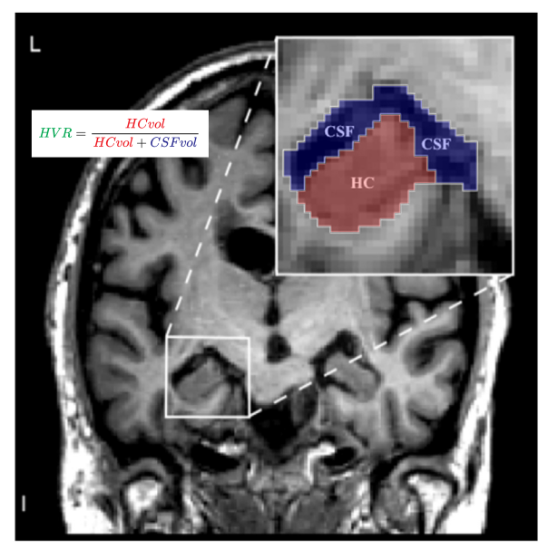

**Why it works**

- Atrophy **↓ numerator**
- Ventricular expansion  
  **↑ denominator**
- Both scale with head size —  
  ratio reduces ICV

Schoemaker’s original manual HVR  
in MCI showed stronger  
age + memory associations  
vs raw HC.

Schoemaker et al., 2019

Background · Normative modeling

GAMLSS models the full distribution, not just the mean

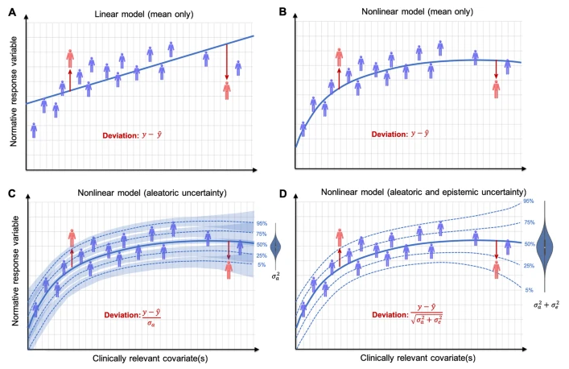

**Standard regression**

Models the **mean** only.

**GAMLSS**

Models **μ, σ, ν, τ**  
(location, scale, skewness, kurtosis)  
as smooth functions of age —  
yields sex-stratified centile curves  
and Z-scores.

**Distribution family**

**BCCG** (Box-Cox Cole-Green)  
selected via AIC/BIC for HVR.  
Pediatric growth chart analogue.

Rigby & Stasinopoulos, 2005 · Bethlehem et al., 2022

Background · Stats methodology

Effect-size measures used in this thesis

| Measure | Formula | Use |
| --- | --- | --- |
| **Cohen’s *d*** | (μ₁ − μ₂) / *s*<sub>pooled</sub> | Balanced groups |
| **Glass’ Δ** | (μ₁ − μ₂) / *s*<sub>control</sub> | Reference-normalized |
| **Hedges’ *g*** | *d* × *c*(*N*) | Small-sample *d* |
| **Spearman ρ** | rank correlation | Non-parametric |

**Interpretation rules of thumb**

- |d| ≈ 0.2 **small**
- |d| ≈ 0.5 **medium**
- |d| ≈ 0.8 **large**

**Bootstrapped 95% CIs** reported throughout via `bootES`.

Kirby & Gerlanc, 2013

Background · SEM

Structural equation modeling 101

**Two parts**

- **Measurement:**  
  latent ← observed (CFA)
- **Structural:**  
  paths between latents

**Fit indices (good cutoffs)**

- CFI / TLI ≥ 0.95
- RMSEA ≤ 0.06
- SRMR ≤ 0.08

**Why use SEM**

- Accounts for **measurement error**  
  in both predictors and outcomes
- Tests **latent constructs**  
  (e.g., *g* from 12 tests in Ch5)
- Multi-group + invariance testing  
  for sex

Bollen, 1989

Background · LGCM

Latent growth curves model individual trajectories

**LGCM extracts**

- **Intercept:**  
  baseline level per individual
- **Slope:**  
  rate of change per individual

**Parallel-process LGCM**

- Two LGCMs (HVR + cognition) jointly
- Correlates **slopes** → coupled decline rate

**Used in Ch6**

- HVR slope ×  
  cognitive slope coupling
- Tests **slope-mediated**  
  CVR → cognition pathway

**Advantages over LME**

- Explicit individual trajectories
- Measurement error in outcomes

Bollen & Curran, 2006 · Raket, 2020

Background · Mediation analysis

Testing whether X → M → Y holds

**Paths in a mediation model**

- **a:** X → M (predictor → mediator)
- **b:** M → Y given X (mediator → outcome)
- **c’:** X → Y given M (direct effect)
- **a·b:** indirect (mediated) effect

**Test**  
bootstrap 95% CI on a·b excludes zero

**Ch6 uses**

- LGCM mediation:  
  **CVR → HVR slope**  
  **→ cognitive slope**
- Tested 6 models:  
  3 cognitive domains × 2 sexes
- Bootstrap n = 1000

Baron & Kenny, 1986 · MacKinnon et al., 2002 · Preacher & Hayes, 2008

Background · Cohort

ADNI — the AD-continuum reference cohort

**Study design**

- Multi-site, multi-scanner, longitudinal
- Launched 2003;  
  phases ADNI 1 / GO / 2 / 3 / 4
- Recruits cognitively healthy, MCI, and AD patients
- T1w + T2 FLAIR + DTI;  
  CSF + amyloid/tau PET;  
  APOE; cognitive battery

**Used in this thesis**

- **Ch3**: QC pipeline applied
- **Ch4**: N = 1,641 baseline T1w
- **Ch6**: A+ longitudinal subset

Jack et al., 2008

Background · Cohort

UK Biobank — population-scale imaging

**Study design**

- Prospective population cohort
- Recruitment ages 40–69;  
  ~500,000 enrolled
- Brain MRI sub-study target: 100,000  
  (>50,000 imaged to date)
- T1w + T2 FLAIR + swMRI + fMRI + DTI;  
  cognitive battery; genetics; lifestyle

**Used in Ch5**

- N = **27,680**  
  with complete imaging + cognition
- Mostly cognitively healthy
- Provides the normative reference  
  for HVR centiles applied in Ch6

Miller et al., 2016 · Alfaro-Almagro et al., 2018

Background · Reliability metrics

Cohen’s κ · Fleiss’ κ · ICC

| Metric | Use | Range |
| --- | --- | --- |
| **Cohen’s κ** | 2 raters, categorical | −1 to 1 |
| **Fleiss’ κ** | ≥3 raters, categorical | −1 to 1 |
| **ICC** | Continuous, multiple raters | 0 to 1 |

**Landis & Koch cutoffs**

- 0.81–1.00 **almost perfect**
- 0.61–0.80 substantial
- 0.41–0.60 moderate
- 0.21–0.40 fair · ≤ 0.20 slight

**Why chance-correct**

Raw percent agreement overstates reliability when one category is common;  
κ subtracts agreement expected by chance.

**Where used in this thesis**

- **Ch3** —  
  Cohen’s κ for expert intra‑rater + trainee-vs-expert QC agreement;  
  Fleiss’ κ for multi-rater consensus
- **Ch5** —  
  ICC for longitudinal test‑retest of brain measures

Cohen, 1960 · Fleiss, 1971 · Landis & Koch, 1977

Background · Image-segmentation validation

Dice · Hausdorff · Bland-Altman

**Dice coefficient**

- Spatial overlap: **2|*X* ∩ *Y*| / (|*X*| + |*Y*|)**
- 0 = no overlap; 1 = perfect
- Volumetric; symmetric; robust to size differences

**Hausdorff distance**

- **Max** surface distance between two label sets
- Boundary-sensitive; catches localised outliers
- Used in CNN training loss

**Bland-Altman**

- **Mean vs. difference** plot — reveals bias, LoA, regression-to-mean

**Why three metrics**

- Dice — overlap volume
- Hausdorff — worst-case boundary
- Bland-Altman — bias across the range

**Where used**  
**Ch4** CNN validation:  
Dice ≈ 0.96 vs manual;  
Hausdorff in loss;  
Bland‑Altman for MALF HC/CSF bias.

Dice, 1945 · Hausdorff, 1914 · Bland & Altman, 1986

Background · Deep-learning segmentation

3D U-Net architecture

**Architecture**

- Encoder-decoder with **skip connections**
- Encoder: downsamples → captures context
- Decoder: upsamples → recovers detail
- Skips: pass spatial info around the bottleneck
- 3D variant: volumetric convolutions

**Loss**

- Dice κ overlap + multi-label Hausdorff approximation

**Training-data scaling**

- Small manual sets are common in medical imaging
- **Data augmentation** multiplies effective training size —  
  Ch4 uses **16×** (rotations, flips, intensity, noise)

**Why U-Net for HC/CSF**

- Designed for biomedical segmentation
- Multi-label output  
  (HC + CSF) in one pass

Ronneberger et al., 2015 · Isensee et al., 2021

Background · Cognitive measurement model

Bifactor CFA — g + orthogonal specifics

**Structure**

- One **general factor (g)** loading on ALL indicators
- Several **specific factors** loading on subsets (e.g., Memory_s on memory items)
- All factors **orthogonal** (uncorrelated by design)

**Partitions**

- g = shared common variance across all tasks
- Specifics = residual domain-specific variance after removing g

**Why bifactor vs higher-order**

- g defined directly by item loadings;  
  no domain-correlation distortion
- Specifics isolated, not confounded with g

**Where used**  
**Ch5**: 12 UKB cognitive tests  
→ g + Memory_s + Speed_s.  
Memory_s could not be reliably estimated (disclosed in limitations).

Reise, 2012 · Eid et al., 2017 · Burns 2020

Background · Cross-group comparison gate

Measurement invariance — 4 nested levels

| Level | What’s constrained | Tests |
| --- | --- | --- |
| **Configural** | Same factor structure | Form |
| **Metric** | + equal loadings | λ |
| **Scalar** | + equal intercepts | τ |
| **Strict** | + equal residuals | θ |

**Decision rules**

- **ΔCFI ≤ 0.01** and **ΔRMSEA ≤ 0.015** between nested levels (Chen 2007; Cheung & Rensvold 2002)

**Why it gates cross-group comparison**

- Without invariance,  
  latent means / paths are not comparable
- Scalar → means comparable;  
  strict → residuals equal

**Where used**

- **Ch5** sex on cognitive bifactor:  
  all 4 levels pass
- **Ch6** sex on CVR<sub>mimic</sub>:  
  metric holds, scalar rejected → partial

Cheung & Rensvold, 2002 · Chen, 2007 · Putnick & Bornstein, 2016

Background · Latent residualization framework

MIMIC — Multiple Indicators, Multiple Causes

**Structure**

- Multiple **observed indicators** → latent factor  
  (measurement model)
- External **covariates as causes** of the latent factor  
  (structural model)
- The latent **residual ζ** is orthogonal to the covariate

**Key equation**

η = γ · age + ζ  
indicators ← λ · η + ε

**Why this beats observed-score residualization**

- Removes age at the **latent (noise‑free) level**
- Preserves the indicators’  
  factor structure

**Where used**  
**Ch6** builds CVR<sub>mimic</sub> from 5 CVR indicators with age as cause:  
γ = 0.125, R² = 0.016 →  
only 1.6% of latent CVR variance  
is age.

Jöreskog & Goldberger, 1975 · Bollen, 1989

Background · Disease-progression time scale

Estimated Disease Time (EDT)

**The problem**

- Calendar time (YRS from baseline) doesn’t align participants on disease stage
- Two participants 5 yrs into ADNI can be at very different points of AD progression

**The fix**

- Joint ADAS-13 + MMSE longitudinal model estimates an **individual disease-time offset**
- EDT = years-from-an-AD-onset anchor on a common scale
- Participants aligned on disease stage, not chronology

**What EDT enables**

- **Pooled trajectories** across CU/MCI/AD on one time axis
- Stage-anchored mediation tests (Ch6 LGCM)

**Disclosure**

- Derived from ADAS-13 + MMSE  
  (same measures used downstream)
- Enters Ch6 as **time axis only, not outcome**

Donohue et al., 2014 · Jedynak et al., 2012

Background · LME moderation framework

3-way interaction: Years × CVR × HVR

**The model**

Cog<sub>it</sub> = β₀ + (β₁ + b₁ᵢ)·YRS  
+ β₂·CVR + β₃·HVR  
+ **β₇·YRS × CVR × HVR**  
+ all lower-order terms + covariates + ε

**Interpretation of β₇**

- Negative β₇ = CVR **weakens** HVR’s protective role on cognition over time
- The 3-way captures whether CVR modulates HVR-cognition coupling longitudinally

**Why all lower-order terms matter**

- 3-way nests with all  
  lower-order terms
- Omitting lower-order **biases**  
  the 3‑way estimate

**Where used**  
**Ch6** main LME inference:  
3-way (FRS) significant in all 6 sex × domain models;  
3-way (CVR<sub>mimic</sub>) mostly null.

Cohen et al., 2003 · Aiken & West, 1991

Background · Indirect-effect testing

Bootstrap CI · FDR · permutation

**Indirect effect (a·b)**

- Product of two coefficients
- Sampling distribution is **skewed**, not normal
- Sobel test is conservative

**Bias-corrected bootstrap**

- Resample with replacement (N = 1,000+)
- 95% CI on a·b adjusts for skew
- **Excludes zero** → significant indirect effect
- Shared-seed lets two predictors be compared on the same resamples

**FDR (Benjamini-Hochberg)**

- Controls false discovery rate  
  (not family-wise)
- More liberal than Bonferroni for correlated tests

**Permutation tests**

- Non-parametric significance via label shuffling
- Ch4 uses 10,000 reps  
  for ρ comparisons

Efron & Tibshirani, 1994 · Benjamini & Hochberg, 1995 · MacKinnon et al., 2002

Background · Quasi-experimental design

Mahalanobis 1:1 matching

**The technique**

- Each **female** matched to one **male** (or vice versa) on multiple covariates jointly
- Distance metric: **Mahalanobis** (accounts for covariate covariance)
- Calipers: age ± 1 yr, ICV ± 25 cc (~0.3 SD)
- Optimal matching minimises total distance globally

**Sample sizes**

- Full UKB: N = 27,680
- Matched pairs: **4,750 × 2 = 9,500**

**Why match instead of regress**

- Removes covariate variance **by design**, not by linear control
- Distributional, not parametric — robust to non-linearity

**Where used**  
**Ch5** ICV-matched pairs:  
HC collapses to ≈ 0,  
HVR persists at d = 0.18.

Ho et al., 2011 · Stuart, 2010

Background · Amyloid-PET standardization

Centiloid scale — amyloid quantification

**The scale**

- Linear transform of tracer SUVR to a **0–100** scale
- 0 = young healthy negative control mean
- 100 = AD-dementia positive mean
- Harmonises across tracers (**florbetapir**, florbetaben, PIB, NAV4694)

**Threshold**

- **> 25** typically defines amyloid-positivity
- Also accepted: CSF Aβ42/40 ratio < cohort-specific cutoff

**Why standardise**

- ADNI uses multiple PET tracers across phases —  
  Centiloid lets results pool

**Where used**  
**Ch6**: A+ defined as PET Centiloid > 25 OR CSF Aβ-positive (combined criterion).  
A−/CU control sample drawn from below-threshold participants.

Klunk et al., 2015 · La Joie et al., 2019

Chapter 3

Qrater

A collaborative and centralized imaging quality-control web application

Chapter 3 · Motivation

Why we needed Qrater

**Visual QC was the bottleneck**

- Thousands of MRI scans needed checking
- Multiple raters had to work in parallel
- Each QC task (raw, registration, segmentation)  
  had its own ad-hoc tool

**Existing tools fell short**

- **Single-user** workflows  
  (VisualQC)
- **Modality-specific**  
  (MRIQC: structural only;  
  pyfMRIQC: functional only)
- Dashboard-style, not designed  
  for rating throughput (Mindcontrol)

Chapter 3 · The tool

Qrater — web-based, containerized, collaborative

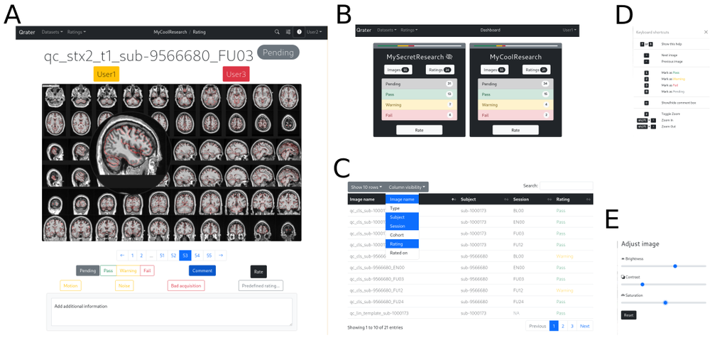

(A) rating window · (B) dataset cards · (C) image list · (D) keybindings · (E) image controls

Chapter 3 · The benchmark tasks

Three QC tasks, three mosaic formats

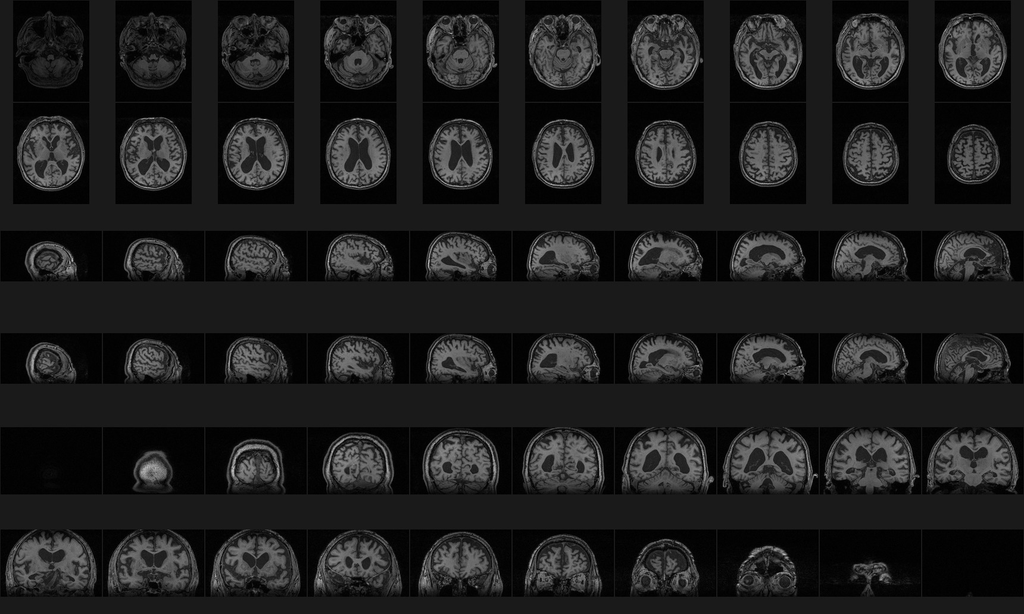

Raw T1w MRI

Native space

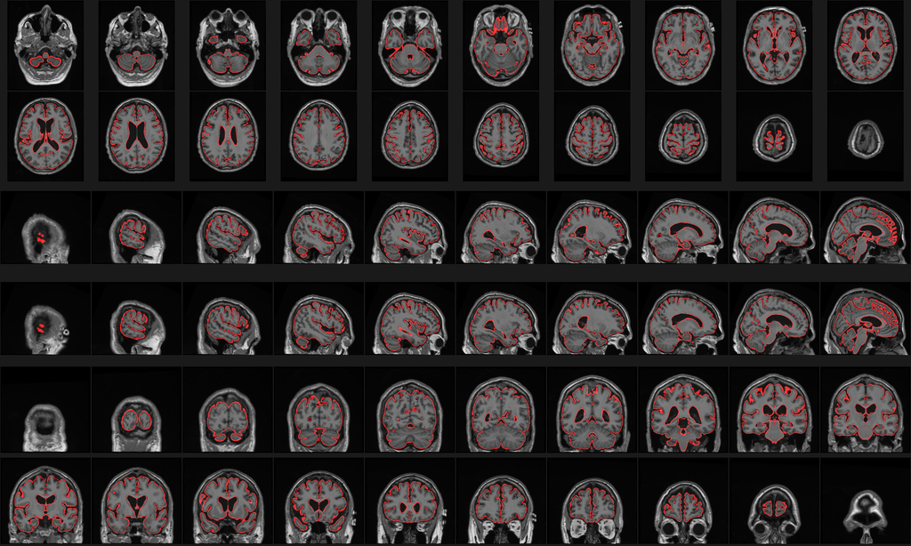

Linear registration

Template overlay in red

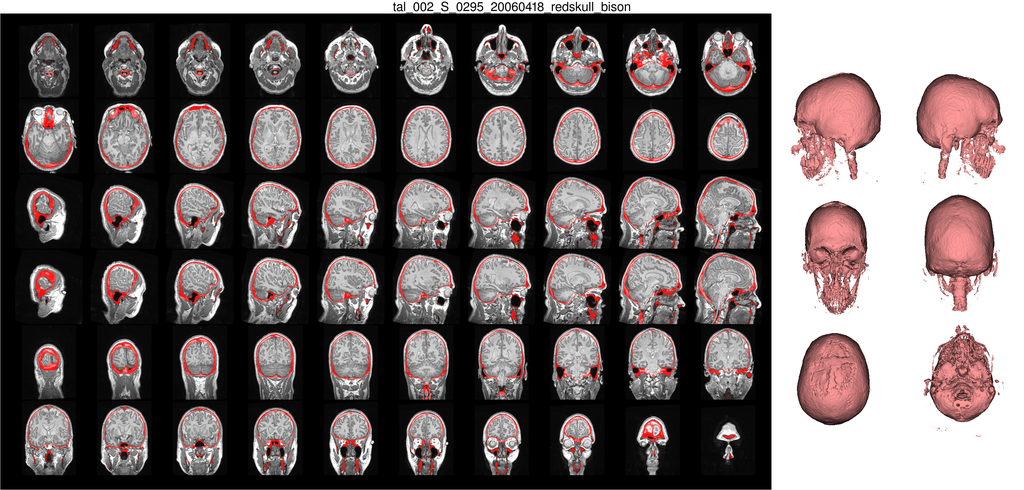

Skull segmentation

Segmentation overlay in red

All formats: 60-slice mosaic (20 axial · 20 sagittal · 20 coronal)

Chapter 3 · Pipeline overview

Mosaic generation  
→ Qrater → ratings

Task-agnostic, modality-agnostic

External scripts produce mosaics.  
Qrater handles rating  
+ central storage.

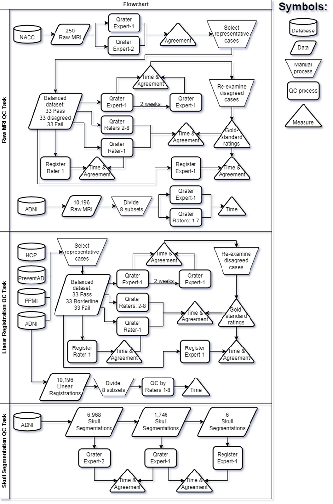

Chapter 3 · Sample

Five public datasets · 11 raters · 20 K+ evaluations

[output not shown]

ADNI N = **10,196** raw / **10,196** reg / **6,968** skull

**Raters**

- 2 **experts**  
  (30+ / 10+ yrs)
- 9 trainees
- Same research team
- Worked remotely on own hardware

Chapter 3 · Speed

Skull-segmentation QC: a 20× speedup

~3 s per mosaic vs ~60 s slice-by-slice

~20×

faster than conventional slice-by-slice inspection

The largest time-savings of the three tasks.  
For ~7,000 ADNI scans: ~115 expert-hours → ~6 hours.

Chapter 3 · Inter-rater agreement

Raw MRI — moderate agreement

Borderline cases drive disagreement; Pass / Fail extremes agree

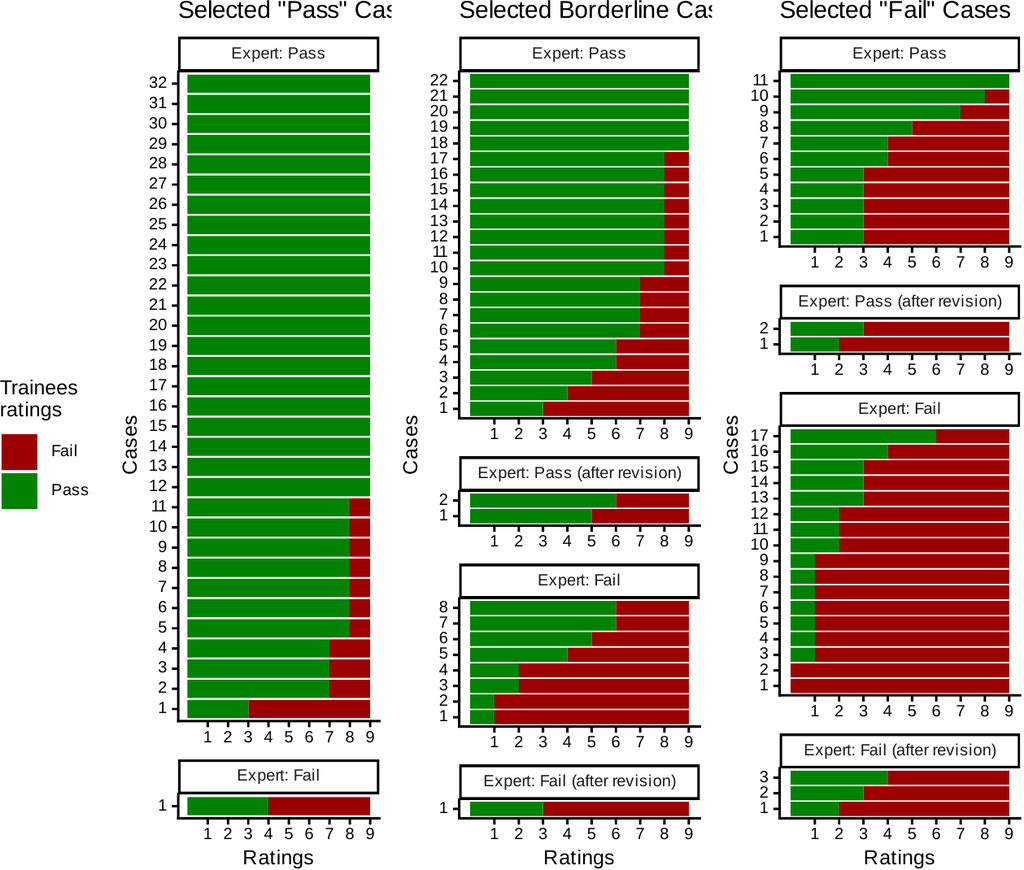

**Trainees vs expert gold standard**

- Bar charts: Pass (green) / Fail (red) trainee votes
- Borderline cases (middle) account for most disagreement
- Consistent with prior raw-MRI QC literature

Chapter 3 · Inter-rater agreement

Linear registration — higher agreement than raw

Template overlay makes misalignment visually obvious

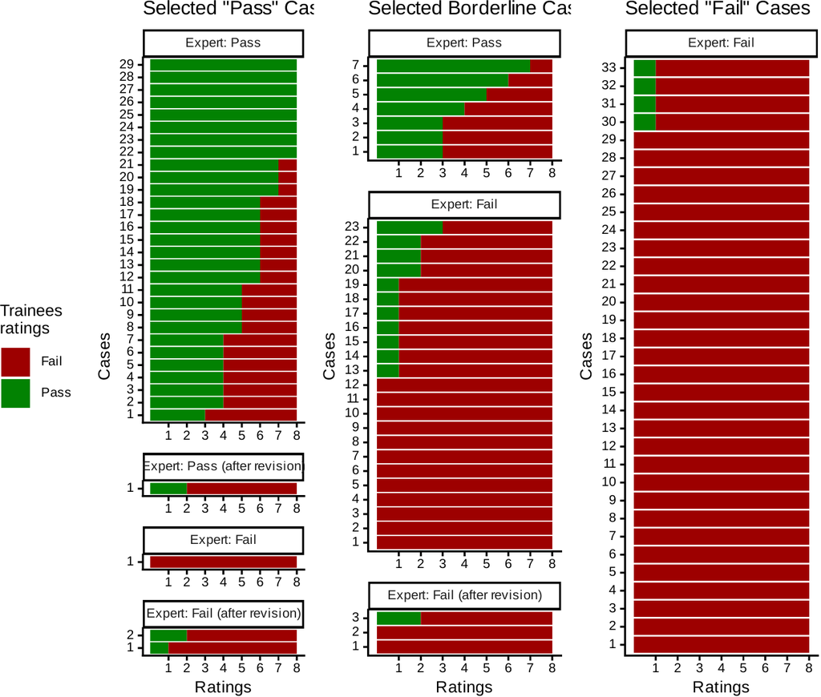

**Trainees vs expert gold standard**

- Red **template overlay** flags misalignment at a glance
- Higher κ than raw MRI
- Practical task to train novices on

Chapter 3 · Inter-rater agreement

Skull segmentation — experts converge

Cohen’s κ = 0.83 between Expert-1 and Expert-2 across 1,746 images

κ = 0.83

Excellent expert-expert agreement on skull segmentation

The clearest task: skull tissue is well-defined, mosaic shows the overlay directly.  
Subjectivity is minimal — and accordingly, two experts converge.

Chapter 3 · Training effect

Trainees converged on the expert with practice

+80%

trainee–expert agreement on the Acquisition-99 balanced set  
(after enough practice time)

Agreement and time on task were significantly correlated:  
more deliberate raters converged closer to the expert gold standard.  
Qrater’s centralized format makes structured training feasible.

Chapter 3 · Speed (full comparison)

Per-task speedup vs conventional viewer

| Task | Rater | Conventional | Qrater | Speedup |
| --- | --- | --- | --- | --- |
| Raw MRI | Expert | 90 imgs / 63 min | 99 imgs / 63 min | **1.1×** |
| Raw MRI | Trainee | 79 imgs / 98 min | 99 imgs / 98 min | **1.3×** |
| Linear registration | Expert | 43 imgs / 36 min | 99 imgs / 36 min | **2.3×** |
| Linear registration | Trainee | 30 imgs / 37 min | 99 imgs / 37 min | **3.3×** |
| Skull segmentation | Expert | ~60 s / image | ~3 s / image | **~20×** |

Chapter 3 · Detailed agreement

Confusion matrix — raw MRI

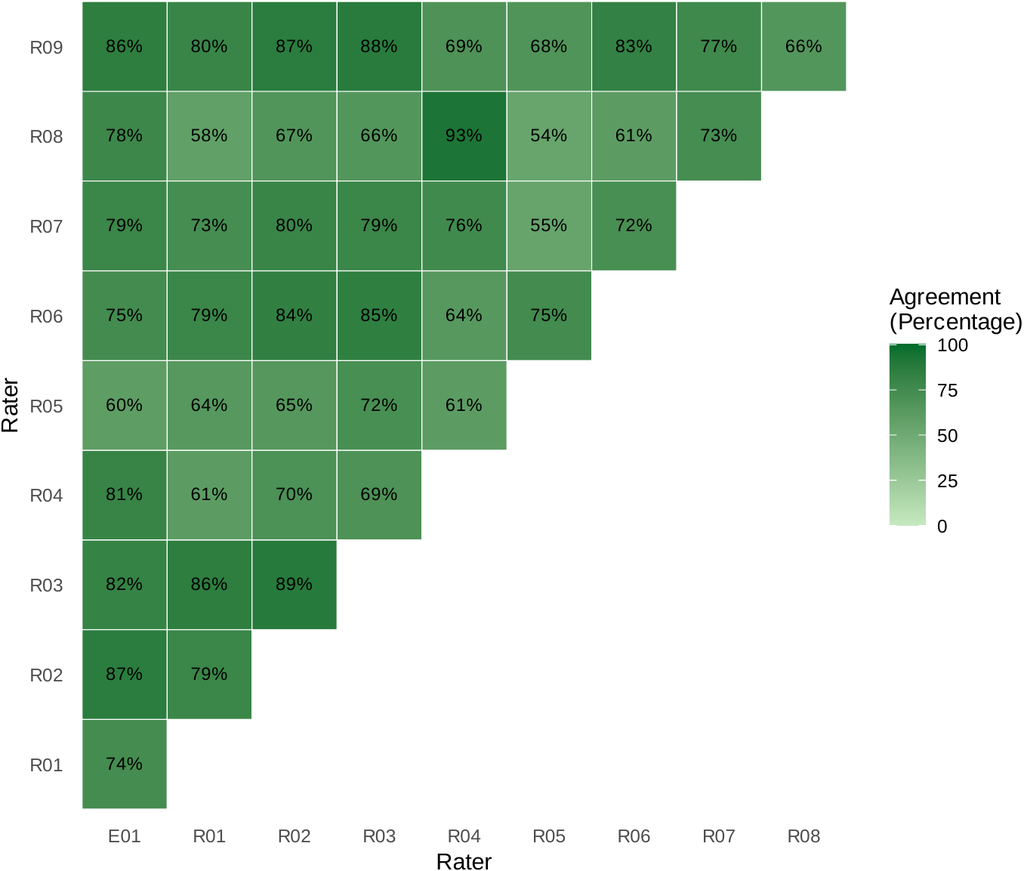

Percent agreement of trainees (R01–R09) with expert gold standard (E01).

Chapter 3 · Detailed agreement

Confusion matrix — linear registration

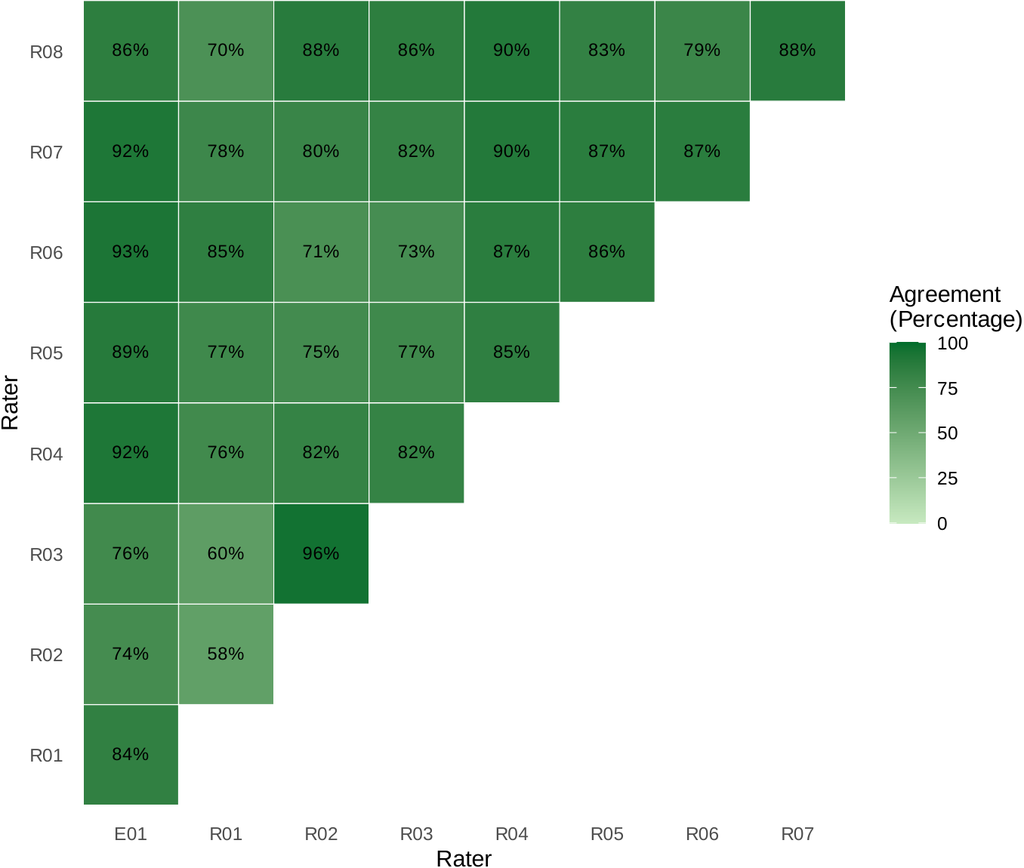

Chapter 3 · Differentiation

Why Qrater fills the gap

| Feature | Qrater | VisualQC | Mindcontrol | MRIQC |
| --- | --- | --- | --- | --- |
| Task-agnostic | **✓** | partial | ✗ | ✗ |
| Multi-user concurrent | **✓** | ✗ | ✓ | ✗ |
| Containerized | **✓** | ✗ | ✗ | ✗ |
| Any 2D rendering | **✓** | ✗ | ✗ | ✗ |
| Open source | **✓** | ✓ | ✓ | ✓ |

**Niche**

**Task-agnostic**, multi-user, containerized — pluggable into any QC pipeline.

Not a replacement for specialized automated QC (e.g., MRIQC) — a manual layer above.

Chapter 3 · Adoption + tools

Qrater in use beyond this thesis

Released on DockerHub + GitHub

250 K+

images on the lab server (current)

Adopted beyond the original project; used by collaborator labs.  
The QC’d ADNI dataset is the foundation for Chapters 4 and 6 of this thesis.

Chapter 3 · Expert self-agreement

How stable is the gold standard itself?

| Task | Intra-rater κ |
| --- | --- |
| Raw QC (Acq 99) | **0.81** |
| Linear registration (99) | **0.87** |
| Skull segmentation | *no balanced set* |

**Why it matters**

- Even expert judgement shifts  
  across sessions
- Sets a realistic ceiling for  
  trainee-vs-expert agreement
- Justifies the revision protocol  
  (next slide)

Landis & Koch, 1977

Chapter 3 · Gold-standard revision

Borderline cases get a second look

**Raw QC (Acq 99)**

- 8 of 99 images had discrepant Expert-1 ratings
- Re-examined → **4 Pass · 4 Fail**
- Final gold standard: 69 Pass / 30 Fail

**Linear registration (99)**

- 6 of 99 discrepant
- Re-examined → **5 Fail · 1 Pass**
- Final gold standard: 62 Fail / 37 Pass

**Protocol**

- Expert-1 re-examined ONLY the discrepant set
- Final decision recorded as gold standard
- Revision completed before trainee QC began

**Why fix before trainee QC**

Prevents post-hoc adjustment  
of the gold standard  
to favour trainee agreement.

Chapter 3 · Disagreement root cause

Trainees see artifacts — they grade them differently

**The observation**

> Raters who marked images as “Pass” often recorded the **same artifacts** in the comments  
> as the raters who marked those same images as “Fail”.

**Implication**

Disagreement is a **subjective threshold** difference,  
not a gross misidentification of artifacts.

**Trainee rationale (follow-up)**

> Several raters explained that they **passed an image**  
> when the artifact found was thought to be **mild enough**  
> (e.g., intensity non-uniformity)  
> to be corrected in downstream preprocessing.

**Why it matters**

Qrater captures qualitative comments alongside Pass/Fail,  
exposing the threshold distinction.

Chapter 3 · Speed–accuracy tradeoff

Slower trainees agreed with the expert more

Spearman correlation across 9 trainees · Acquisition 99

ρ = 0.77

Total QC time vs agreement with Expert-1

*S* = 28 · *p* = 0.021 · N = 9 trainees  
Deliberation tracks accuracy — but Qrater’s mosaic + automation still cuts expert time ~20×.

Chapter 3 · ADNI deployment

8% non-Pass — even on ADNI’s QC’d data

4.8% / 3.1%

Warning / Fail in 10,196 ADNI baseline scans

Pass: 9,387 (92%) · Warning: 491 · Fail: 319  
ADNI completed its own QC; Qrater’s 3-tier labelling flagged additional cases where preprocessing should be tracked closely (Warning) or the scan excluded (Fail).

Chapter 3 · Reproducibility

Container stack: pluggable into any pipeline

**Open release**

- Source: github.com/soffiafdz/qrater
- Image: hub.docker.com/r/soffiafdz/qrater
- Analysis: github.com/soffiafdz/qrater_analysis

**Stack**

- Flask + SQLAlchemy (app server)
- MySQL 8.0.25 (data)
- Redis 6.2.4-alpine (rate-limit, cache)
- Docker Compose (orchestration)

**Why containerized**

- Single-command deploy  
  (`docker compose up`)
- Versioned services — bit-identical replication
- No host-side install dependencies

**Adopted beyond thesis**

Collaborator labs, multiple cohorts.  
ADNI Qrater dataset is the foundation  
for Ch4 + Ch6.

Chapter 3 · What Qrater is not

Known limitations

**Limitations (from the chapter)**

- **JPEG lossy** compression — small artifacts could be confused with susceptibility / flow noise
- **External mosaic generation** — Qrater rates pre-rendered 2D images; pipeline must produce them
- No **automatic quality-metric extraction** or QC-status prediction
- Test-retest was unblinded — possible recall
- **Remote rating** factors not controlled (environment, monitor)
- Time measurement coarse — gaps > 15 min excluded as “away”

**Mitigation already in place**

- **PNG (lossless)** format is already supported in Qrater for sites that prefer it
- Qrater is task-agnostic — automated QC tools can produce its mosaic input

**Scope**

Qrater is a **manual layer above automated QC**,  
not a replacement for tools like MRIQC.

Chapter 4

HVR Validation

Automated CNN-based segmentation  
and clinical benchmarking in ADNI (N = 1,641)

Chapter 4 · Motivation

Why automate HVR?

Manual segmentation doesn’t scale

**The bottleneck**

- Manual HC + temporal-horn segmentation  
  ≈ **2 h / subject** (Schoemaker 2019)
- High intra- and inter-rater variability
- Biobank-scale HVR is infeasible  
  without automation

**Goal**

- Accurate, **joint HC + ventricle** segmentation
- Validated against manual gold standard
- Applied to ADNI N = 1,641

Schoemaker et al., 2019 · Dill et al., 2015

Chapter 4 · Study design

The pipeline in one view

| Stage | N | Purpose |
| --- | --- | --- |
| **Training labels** | **80** | manual HC + CSF gold standard |
| **Cross-validation** | **64 / 16** | train / val per fold |
| **Out-of-sample** | **60** | 20 CH / MCI / AD — generalization |
| **Clinical application** | **1,641** | ADNI baseline — CH:AD effects |

**Methods compared**

- **MALF** (multi-atlas label fusion)
- **NLPB** (non-linear patch-based)
- **CNN** (3D U-Net)
- **FreeSurfer** v4.3 / 5.1 / 6.0

Chapter 4 · Segmentation methods

Four families, one head-to-head

| Method | Type | Detail |
| --- | --- | --- |
| **MALF** | atlas-based | label fusion via ANIMAL |
| **NLPB** | patch-based | non-linear template + local patch similarity |
| **CNN** | deep learning | 3D U-Net, Dice + Hausdorff loss, 16× aug. |
| **FS v4.3 / 5.1** | atlas+surface | ADNI’s released volumes |
| **FS v6.0** | atlas+surface | run locally |

**Why these**

- Only methods that segment  
  **both HC and temporal-horn CSF**  
  (required for HVR)
- FS v6.0 (2017) predates  
  DL-based subfield modules
- nnU-Net / HippoDeep cover HC only  
  (no LV)

Collins et al., 2010 · Coupé et al., 2011 · Fonov et al., 2012 · Ronneberger et al., 2015 · Fischl 2002

Chapter 4 · Network design

3D U-Net with HC + CSF joint output

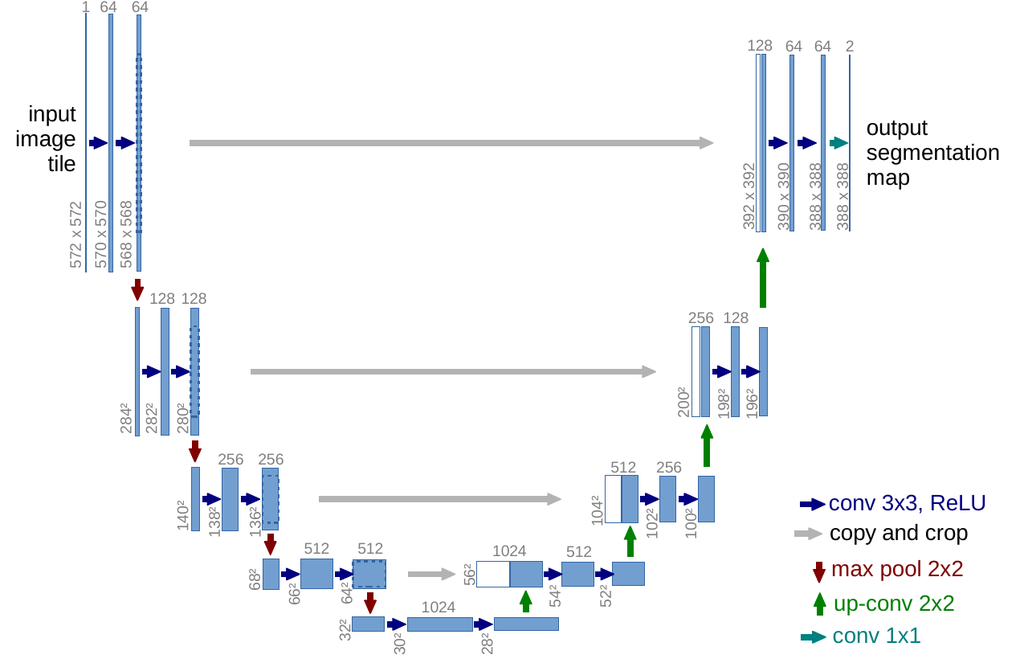

**Training**

- **5-fold CV** (64 train / 16 val)
- 200 epochs/fold
- **16× augmentation**: geometric + intensity + noise

**Loss**

- Dice κ overlap
- Multi-label Hausdorff approximation

Ronneberger et al., 2015 · Fonov et al., 2022 (architecture details)

Chapter 4 · The manual gold standard

Pruessner protocol, 80 healthy subjects

[figure not shown]

**Why this protocol**

- Same expert protocol as  
  **Schoemaker 2019**  
  (direct comparability)
- HC + perihippocampal CSF —  
  both labels required for HVR
- N = 80 from the established template library

**Out-of-sample**

60 ADNI subjects (20 / group)  
re-segmented manually.

Pruessner et al., 2000 · Collins et al., 2010 · Schoemaker et al., 2019

Chapter 4 · Preprocessing

Identical pipeline across methods

**Common preprocessing**

- Denoising (Coupé 2008)
- N3 intensity inhomogeneity correction (Sled 1998)
- Linear histogram normalization
- Affine registration to ADNI-1 stereotaxic template (Fonov 2011)

**Per-method exceptions**

- MALF / NLPB / CNN: all use the common pipeline
- FreeSurfer: uses its own internal preprocessing (cannot intervene without breaking the pipeline)

Coupé et al., 2008 · Sled et al., 1998 · Fonov et al., 2011

Chapter 4 · Cross-validation

CNN dominates on every overlap metric

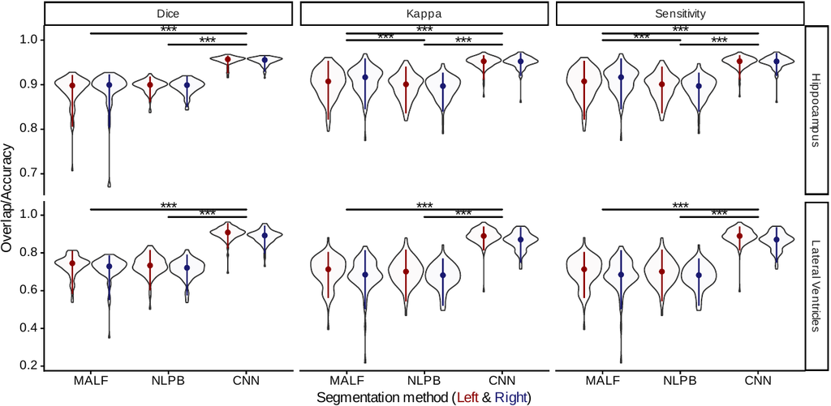

HC Dice ≈ **0.94–0.96** · CSF Dice ≈ **0.87–0.91**  
All FDR-adjusted *p* < 0.001

Chapter 4 · Volumetric correlation

CNN volumes track manual at ρ ≈ 0.99

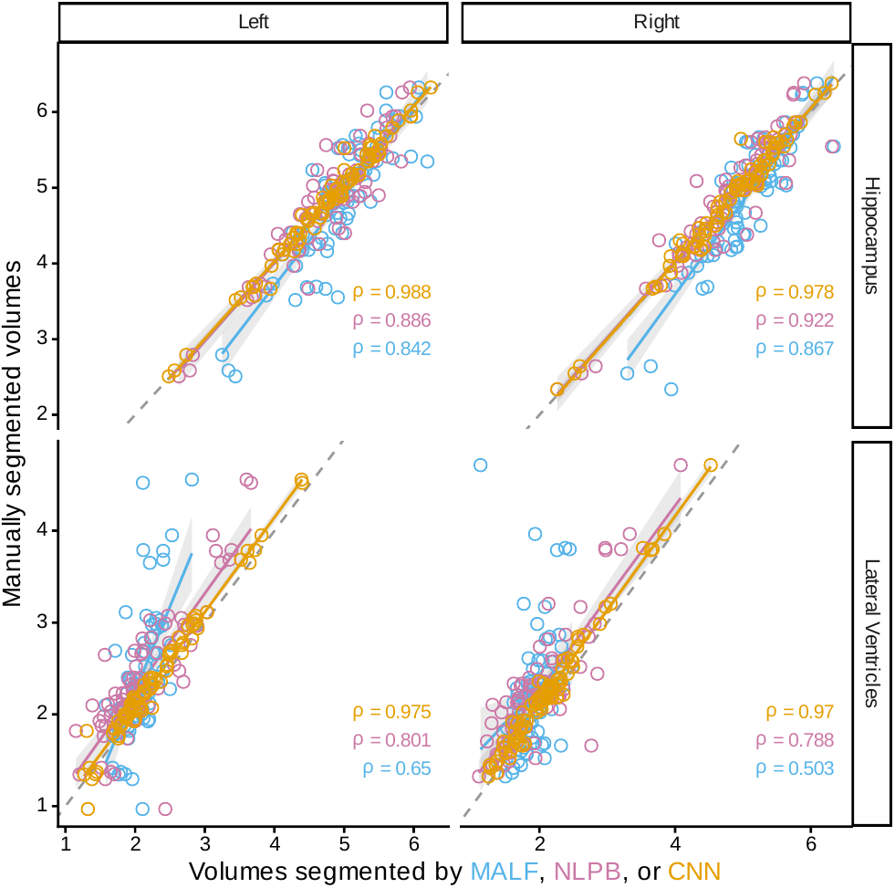

Chapter 4 · Generalization test

CNN holds up on AD-stage volumes

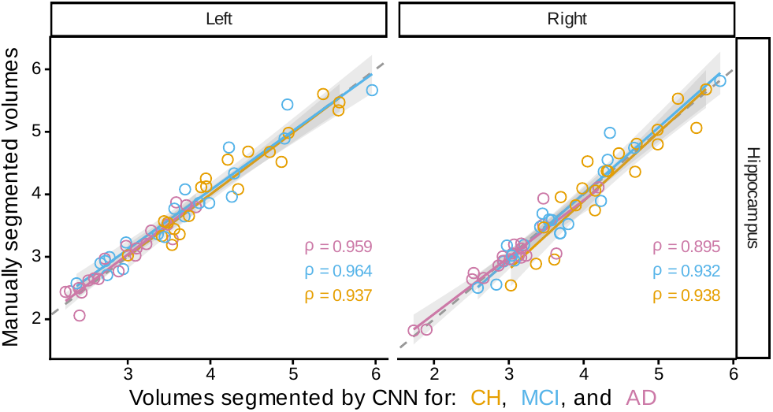

Chapter 4 · Pipeline reliability

CNN: 2 failures across 1,641 scans

Practical reliability for downstream chapters

0.1%

CNN failure rate on the ADNI baseline

NLPB 0.9% · MALF 1.5% · FreeSurfer v6.0 1.5% · FreeSurfer v4.3 / 5.1 ≈ 14% missing in the ADNI UCSF release.

Klapwijk et al., 2019

Chapter 4 · Cross-method validity

HC volumes converge across methods

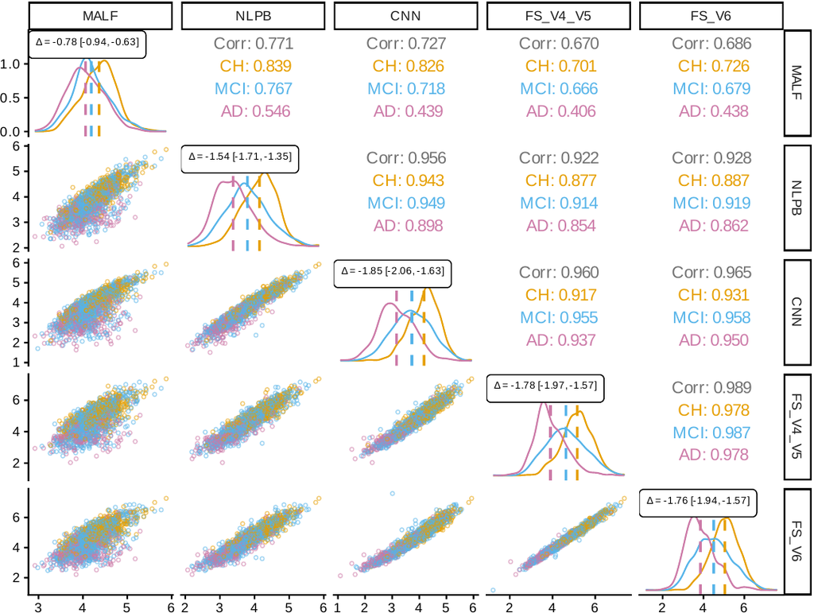

Cross-method ρ = **0.91–0.99**, with MALF the outlier in AD  
CH:AD effect size shrinks where methods disagree most (MALF Δ = −0.78 vs CNN −1.85)

Chapter 4 · The HVR payoff

HVR amplifies effect sizes across all methods

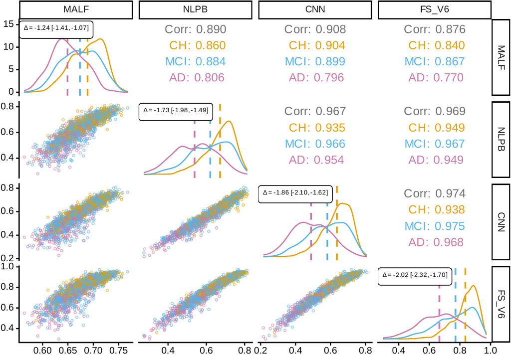

Chapter 4 · Brain–behavior associations

HVR strengthens age associations across methods

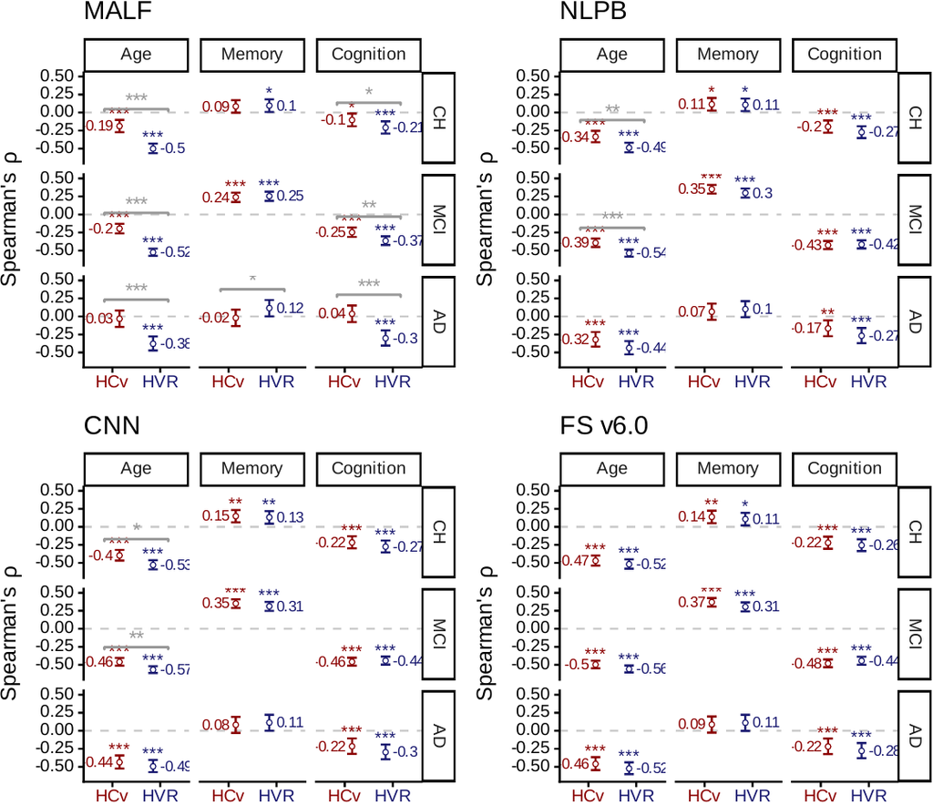

HVR–age correlation is significantly stronger than HC–age for every method except FreeSurfer v6.0  
MALF improvement is the most dramatic (AD: ρ rescues from −0.03 to −0.38)

Chapter 4 · Memory associations

Memory: a nuanced picture

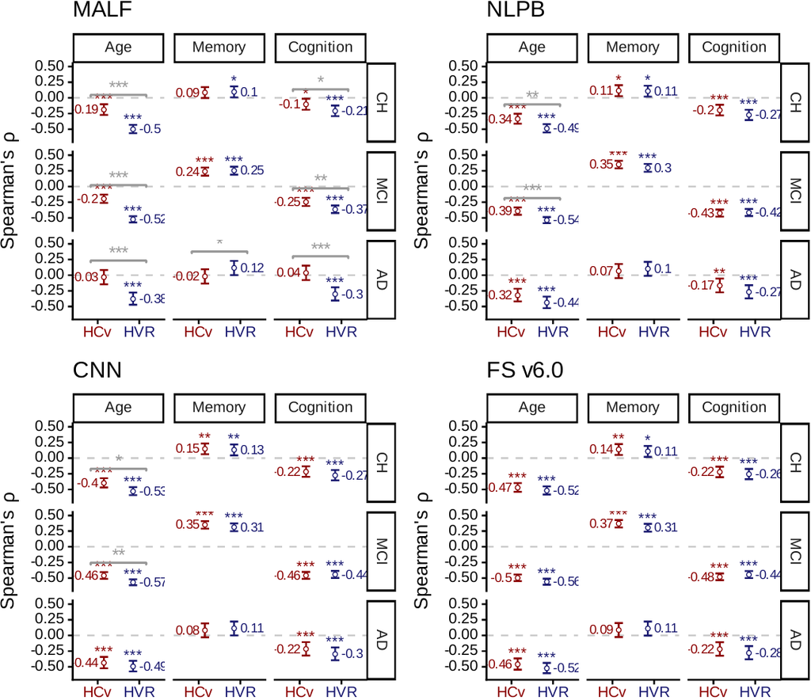

**RAVLT learning**

**ADAS13**

- HVR sig. **all groups, methods**  
  (ρ = −0.21 to −0.44)
- HVR > HC only for MALF

Schoemaker et al., 2019 · van Petten 2004 · Kueper et al., 2018

Chapter 4 · Honest disclosure

CNN ≈ FreeSurfer v6.0 for HVR associations

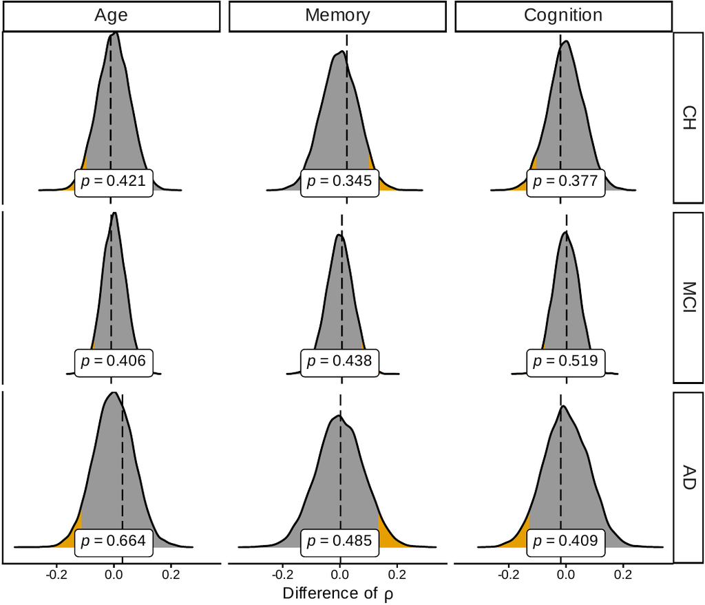

**What FreeSurfer v6.0 matches**

- HVR age associations
- HVR cognition associations
- Permutation tests: all n.s.

**Where CNN wins**

- **Reliability**: 0.1% vs 1.5% failure
- **Joint HC + ventricle** segmentation
- **Open-source, Docker-deployable**

Chapter 4 · Systematic bias check

CNN minimal bias; MALF regression-to-mean

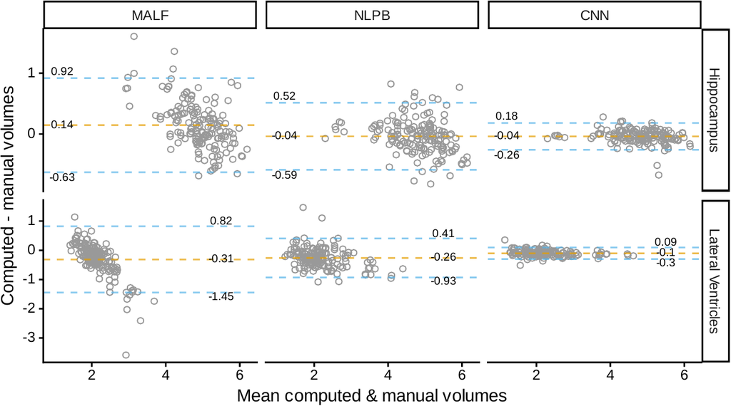

CNN: minimal bias, narrow limits of agreement  
MALF: regression-to-mean on HC; all methods slightly under-segment CSF

Zandifar et al., 2017 · Pipitone et al., 2014

Chapter 4 · Hemispheric effects

Laterality: small, not pathology-driven

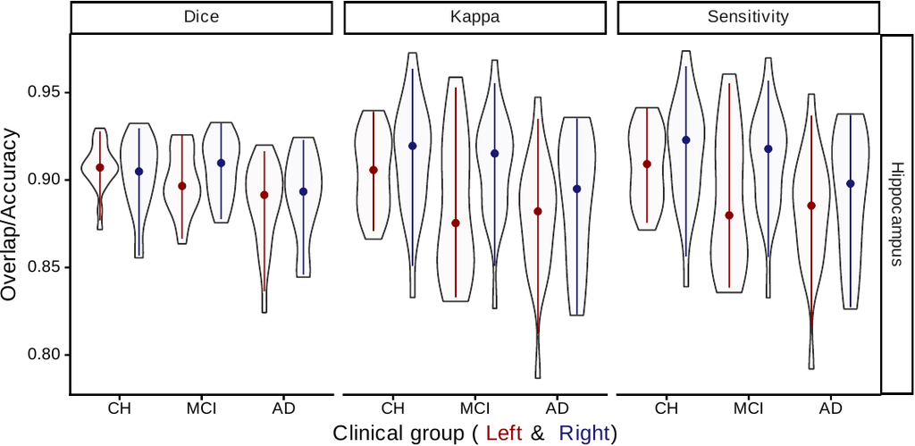

**HC laterality**

**CSF laterality**

- NLPB + CNN: left > right
- No group × side interaction

Chapter 4 · Defending the choice

Why HVR over ICV-corrected HC volume?

| Measure | What it captures |
| --- | --- |
| **HC volume** | atrophy only |
| **HC / ICV** | atrophy + global head size |
| **HC residualized** | atrophy with linear ICV removed |
| **HC occupancy** | atrophy + local space |
| **HVR** | **atrophy + ex-vacuo dilation jointly** |

**Principled answer**

- HVR uses **local CSF** (ex-vacuo dilation) — isolates MTL change
- ICV is a global proxy — doesn’t track local processes
- HC occupancy (Heister 2011) precedent
- Direct HVR-vs-HC/ICV head-to-head is future work

Schoemaker et al., 2019 · Heister et al., 2011 · Whitwell et al., 2012

Chapter 4 · Alternative DL methods

Why not HippoDeep / nnU-Net / FastSurfer?

| Tool | Issue for HVR |
| --- | --- |
| **HippoDeep** | HC only, no temporal-horn label |
| **nnU-Net** (HC models) | HC only, framework not pre-trained on this label set |
| **FastSurfer / FS7** | HC subfields, no joint HC + LV (different anatomy) |
| **Other literature U-Nets** | Dice ≈ 0.89–0.93 — comparable or below this CNN’s 0.96 |

**Bottom line**

- Only methods producing **joint HC + temporal-horn CSF** were eligible
- Literature DL methods focus on HC alone
- This CNN’s Dice (≈ 0.96) matches or exceeds published DL benchmarks

Yi et al., 2021 · Xie et al., 2018 · Amoroso et al., 2015

Chapter 4 · Sample composition

ADNI baseline: N = 1,641

| Group | N | Age (yrs, mean ± SD) | % Female |
| --- | --- | --- | --- |
| **CH** | 501 | 74.3 ± 5.7 | 52% |
| **MCI** | 819 | 72.9 ± 7.6 | 41% |
| **AD** | 321 | 74.8 ± 7.8 | 45% |

**Notable contrasts**

- Sex sig. different in CH (p = 0.002) and MCI (p = 0.004); not AD
- MCI **younger** than CH (Z = 2.6, p = 0.014)
- MCI younger than AD (Z = 4.03, p < 0.001)
- CH–AD age comparable (n.s.)

Chapter 4 · Limitations

What this chapter does not claim

**Sample**

- ADNI: white, educated
- Cross-sectional (Ch6 longitudinal)
- Sex excluded (Ch5)

**Method**

- No scan-rescan
- No nnU-Net / FS v7+
- FS comparison differs in anatomy

**Mitigations**

- Ch5 tests in UKB (N = 27,680)
- Ch6 tests longitudinal A+ ADNI
- HVR invariance to seg method (Slide 12)

Chapter 4 · Reproducibility

Open-source release

Docker container + GitHub repo

**GitHub**

github.com/soffiafdz/hvr_validation

**Docker Hub**

hub.docker.com/r/soffiafdz/hvr_cnn

**Feeds downstream**

- The pipeline is the foundation for **Ch5** (UK Biobank N = 27,680)
- And **Ch6** (ADNI longitudinal A+)

Chapter 4 · Class-wise performance

Beyond Dice — sensitivity & specificity

**Reported in Supp. Table S1**

- Median + SD per method, per structure, per hemisphere
- Five metrics: accuracy, Dice, κ, sensitivity, specificity
- Both bilateral HC and CSF

**Chapter quote**

> Accuracy and specificity for both HC and CSF segmentations **approached 1.0** across all methods and are therefore not included in the figure.

**Why Dice + κ in the main figure**

- Dice / κ have the visible spread across methods
- Accuracy + specificity saturate near 1.0
- Sensitivity follows the Dice pattern for HC

**Where the values live**

Supplementary Table S1 reports the full grid;  
the main figure highlights the metrics  
that distinguish methods.

Chapter 4 · Demographics — sex

Sex distribution differs by group

**ADNI sex distribution (χ²)**

| Group | p (χ², sex) |
| --- | --- |
| CH | **0.002** |
| MCI | **0.004** |
| AD | 1.00 |

**Why Ch4 does not stratify**

- Chapter 4 is methodological validation — scope is **segmentation**, not biology
- Sex × HVR is the dedicated focus of Chapter 5 (UKB N = 27,680)

**Anticipated Q**

- “You have sex imbalance — did you test?”
- “Why not stratify analyses here?”

**Answers**

- Yes — χ² is reported in the demographics table
- Stratifying by sex within Ch4’s small clinical subgroups would underpower the segmentation comparisons; Chapter 5 has the sample size for it

Chapter 4 · Bland-Altman CSF

All methods underestimate CSF — anatomy, not bug

**The pattern (Bland-Altman)**

- **All methods** underestimate CSFvol on average
- **MALF** additionally shows regression-to-mean: over-segments small HC, under-segments large HC
- MALF also under-segments larger ventricles

**Anatomical reason**

The temporal horn of the lateral ventricle has **arbitrary anterior and posterior borders** —  
a much smaller region than HC  
with less landmark anchoring.

Chapter 4 · Training-data scaling

Why 16× augmentation — small training set

**Set sizes**

- Manual gold standard: N = 80
- Train / val per fold: 64 / 16
- 5-fold CV
- Out-of-sample test: N = 60 (20 CH / MCI / AD)

**16× augmentation**

- Geometric transforms (rotation, flip, scaling)
- Random signal shifts
- Intensity amplification
- Voxel-level additive noise

**Why this much**

- 64 training scans is small for a 3D U-Net (typical: hundreds–thousands)
- Validates on truly held-out N = 60  
  across CH / MCI / AD
- 200 epochs per fold, Dice + Hausdorff loss

Chapter 4 · Where the comparison lives

Why HVR over ICV-corrected HC — Ch4 vs Ch5

**Chapter 4 scope**

- Establishes HVR formula + reliability
- Validates HVR rescues clinical effect sizes across methods (CH:AD Δ slide)
- Does **not** directly compare HVR to HC/ICV correction families

**Chapter 5 delivers the comparison**

- HVR vs raw / proportions / stereotaxic / residualized HC
- Δd swings 1.5 SD across HC correction methods
- HVR stays consistent across methods (d ≈ +0.52)

**Anticipated Q**

- “Why HVR and not HC/ICV?”

**Two answers**

1. **Principled** — HVR uses local CSF (ex-vacuo dilation), ICV is a global proxy
2. **Empirical** — Ch5 shows HC/ICV methods reverse direction; HVR doesn’t

**See**

Ch5 headline result (forest plot).

Chapter 4 · Out-of-sample laterality

AD right-HC ρ = 0.90 vs left ρ = 0.96 — not pathology-driven

**The numbers**

- AD: right ρ = **0.90** · left ρ = **0.96**
- MCI: right ρ = 0.93 · left ρ = 0.96
- CH: ρ ≈ 0.94 both sides

**Interpretation (from chapter)**

**Why disclose**

A committee will spot the asymmetry  
in the out-of-sample correlations.  
Better explained than discovered.

Chapter 4 · Reliability ceiling

Is the manual gold standard actually gold?

**Manual is imperfect (cited in chapter)**

- Up to **~2 hours per subject** (Schoemaker 2019)
- High **inter- and intra-rater variability** even among experts (Dill 2015)

**Where CNN sits**

- Dice ≈ **0.96** vs manual labels
- Spearman ρ ≈ **0.99** for HC volumes

**What chapter does NOT claim**

- Inter-rater noise floor is not quantified here
- Whether CNN reaches a rater-noise ceiling is open

**Implication (cautious)**

- High CNN-vs-manual agreement against a known-noisy gold standard
- The cited references frame the limits of manual labels but the chapter stops short of quantifying the ceiling

**Practical value**

- CNN is **reproducible** — no session drift; one fixed function
- Qrater + CNN: automated baseline + manual exception review

Chapter 4 · Reliability context

CNN 0.1% — not just ADNI data quality

| Pipeline | Success rate |
| --- | --- |
| CNN | **99.9%** |
| FreeSurfer v6.0 | 98.5% |
| MALF | 98.5% |
| NLPB | 99.1% |
| FreeSurfer v4.3 / 5.1 (ADNI release) | 86% |

**Independent benchmark**

- Klapwijk 2019 QC of FreeSurfer v6.0:
  - **5%** marked Fail
  - **20%** marked Doubtful
- Our 1.5% FS failure rate is on the optimistic side

**Takeaway**

CNN reliability isn’t an ADNI artifact.  
It generalises to real-world QC standards.

Chapter 5

Sex Differences in UK Biobank

HVR as a head-size-independent biomarker · N = 27,680 UKB participants

Chapter 5 · Motivation

HVR at population scale

Bridging Ch4 (pipeline) to Ch6 (clinical use)

**Three contributions**

- Automated HVR applied at scale  
  (N = 27,680)
- HC sex-difference inconsistency  
  is a **methods artifact**
- Sex-specific GAMLSS norms  
  feed the clinical cohort in Ch6

**Why this matters**

- Settles a long-standing literature inconsistency  
  (needs N > 10⁴)
- Demonstrates HVR generalizes beyond ADNI clinical samples

Schoemaker et al., 2019 · Fernandez-Lozano et al., 2025

Chapter 5 · Research questions

Three specific aims

**Q1 — Adjustment-method sensitivity**

Do HC sex differences vary across ICV adjustment methods while HVR stays consistent?

**Q2 — Age trajectories**

Do age patterns differ by sex? Does HVR capture both HC + LV trajectories?

**Q3 — Brain–cognition**

Does HVR predict cognition comparably to ICV-corrected HC?

**Anchored in**

- 4 standard adjustment methods (raw, proportions, stereotaxic, residualized)
- ICV-matched sub-sample
- GAMLSS sex-specific norms
- Bifactor SEM

Chapter 5 · Sample selection

Figure 5.1 — participant selection flow

Three exclusion stages:  
(1) QC (DARQ + AssemblyNet),  
(2) neurological history (G/Q codes),  
(3) psychiatric history (F codes).  
Dashed boxes are analytic subsamples  
derived from the primary cohort.

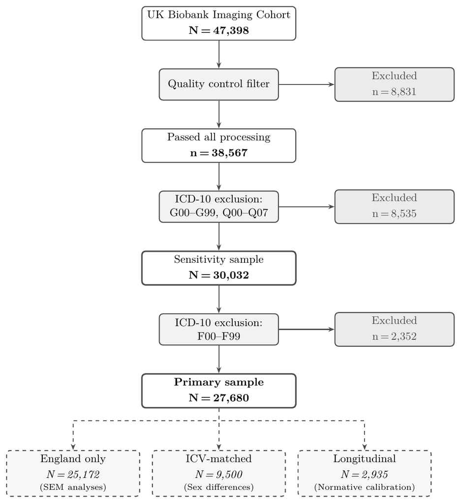

Sudlow et al., 2015 · Miller et al., 2016

Chapter 5 · Quality control

3-stage QC defends T1-only HVR

**Stage 1 — automated**

- **DARQ ≥ 0.25** (registration QC)
- **AssemblyNet “A”** (segmentation QC)

**Stage 2 — outlier flagging**

- ±3 SD age- and ICV-adjusted residuals on HC + LV

**Stage 3 — visual**

- Manual inspection of all flagged volumes

**Why conservative**

- Small structures: minor failures = large relative errors
- No UKB manual ground truth for HC — Stage 1 + 2 are the only signal
- Same QC pipeline applied to ADNI in Ch6

Fonov et al., 2022 (DARQ) · Coupé et al., 2020 (AssemblyNet)

Chapter 5 · Sample characteristics

N = 27,680 · 56% female · ages 45–82

|  | Females (N ≈ 15,500) | Males (N ≈ 12,200) |
| --- | --- | --- |
| **Age (mean ± SD, yrs)** | ≈ 63.7 ± 7.4 | ≈ 64.4 ± 7.5 |
| **ICV (mean ± SD, mL)** | ≈ 1,395 ± 110 | ≈ **1,580** ± 122 |
| **Education (yrs)** | ≈ 15.2 | ≈ 15.4 |
| **HC volume (mL)** | smaller (raw) | larger (raw) |

Males have ~12% larger ICV (Ruigrok 2014) —  
the foundational confound for any HC sex-difference analysis.

Chapter 5 · Adjustment methods

Four standard ICV adjustment methods compared

| Method | Formula | Assumes |
| --- | --- | --- |
| **Raw** | *V* | no correction |
| **Proportions** | *V* / *ICV* × 1000 | isometric: *V* ∝ *ICV* |
| **Stereotaxic** | *V* × \|*J*\| | template-space removes ICV |
| **Residualization** | *V* − β̂(*ICV* − *ICV*̄) | linear *V* vs *ICV* |

**The problem**